# 海红投资期货策略回测和验证

---2019/12/17, 杜少伦

海红投资的期货投资策略主要基于因子模型的量化组合，结合期货盘面趋势数据，交易所库存数据和对应的股票行业指数进行趋势判断。具体来说有以下几点：

- 库存
- 价格曲线（基差和远期）
- 商业利润指数（商品对应的股票板块指数）
- 季节因素
- 盘面均线信号

做多和做空信号的定义如下：

- **做多信号 = （低库存%+季节上行概率大于0.4）+（价格上破55日均线+基差倒挂+股票板块指数上破55日均线）**
- **做空信号 = （高库存+季节下行概率大于0.4）+（价格下破55日均线+基差正向+股票板块指数下破55日均线）**

总的来说，我的开仓依据是中长期趋势走好的情况下做趋势跟踪单。这里逐步解释一下各个因子的选取方法和计算方法：

- **历史因子**：以下两个因子都是在每年年初已经完全确定的因子，不会随着年内时间变化而变化，每年更新一次。
  - 库存因子：这里只考虑交易所库存因子，由于数据限制，商业库存数据的误差很大难以信任，所以追踪仓单的变化已经能够起到不错的效果。这个因子主要是追踪最近五年以来的交易所库存变化，然后对比当前的库存是否处在五年以来库存的相对低位或者高位。这一考虑目前还是比较主观的决定，主要依据当前库存水平和相对库存变化趋势。
  - 季节因子：季节因子是个很重要的商品趋势走势判断依据，大多数商品会随着生产和销售出现明显的季节波动，这里统计的方法是以月度为单位回测历史5年以内的回报情况，保证在做多或者做空时候不踏入明显的逆季节陷阱。同时如果季节因子顺应操作需求，那么可以考虑增加开仓头寸。
- **盘面因子**：以下三个因子都是随着盘面变化而变化的，所以在每次开仓之前才能够完全确定，动态实时更新。
  - **价格因子**：这里采用55日均线作为多空分界线，这个取法很主观但却有效，高于55日均线以上的交易不能做空，低于55日均线以下的交易不能做多。同时每次开仓之前尽量靠近55日均线附近进行。这个因子是我们的生命线因子。
  - **基差因子**：这个又叫做远期曲线因子，基差对于商品交易来讲尤为重要主要反映了商品近期供给和需求情况，在一般情况下商品的远期由于三大费用（仓储，保险和利息）会高于近期，而高出部分的比率应该大体上符合这三部分相加的费率。一旦商品的近期开始反向高于远期，很可能是因为短期缺少现货。同样的一旦商品的远期大幅高于近期，很可能是因为近期供过于求。
  - **股票因子**：这个因子是我们自己构建的股票对应商品的板块指数追踪，如果一个行业的整体股票指数上行，大概率预示着这个行业的需求开始好转或者价格开始提高。因为股票指数对应着行业的盈利能力，这种盈利能力来自需求和供给，需求的提高会导致周转率的提高，从而提高盈利。同时供给的减少会影响价格上行，提高利润率从而短期提高盈利能力。如何构建行业股票指数请参考我另一篇文章《商品对应股票指数的构建》。

下面我将会分以下几部分来做策略回测，同时给出操作总结和改进方案：

- **回测数据选取和指数构建**
- **历史回测模型信号构建**
- **关于仓位管理模型改进**
- **操作预期**

## 回测数据选取和指数构建

这里我们使用历史数据直接来自交易所每日公布的行情数据，包含开盘，收盘，最高，最低，成交量，持仓量。库存数据同样直接来自交易所每周公布的库存周报，我们只选取各个品种的库存总数，不在细分不同地区的库存变动。

- 数据范围：模型构建（2014年开始到2018年末结束），模型检测（2019年初开始到2019年末）。这样选取的理由是我们的模型属于趋势跟踪模型，不需要进行大量的样本外检测，同时趋势走势和时间序列直接相关，所以我们不能进行打乱时间排序的交叉检验。宏观趋势追踪模型是需要以来经济周期的，所以我们选取五年的历史数据和一年的最新数据进行模型验证。同样的道理我们可以使用2013年到2017年的历史数据来构建模型，从而对2018年的行情进行模型检验。
- 指数构建：这里的模型回报和检测都是基于商品指数进行的，不进行各个具体合约回报的计算。这样做会产生一些误差，但是极大地简化了计算量，同时不影响模型和合理性假设。这里的各个商品指数构建方式如下：
  - 给定日期的给定商品，计算最大三个活跃合约的持仓量和收盘价的加权平均最为该天的商品收盘价。
  - 给定商品的对应股票指数，计算当下正常经营的生产商的股票收盘价格按主营业务占有率的加权平均价格作为该天的股票指数收盘价。具体如何选取对应的股票，这里不再重复。

*注意： 所有的回测数据全部储存在"stock_data.xlsx","future_data.xlsx"和"inventory_data.xlsx".

## 历史回测和信号建立

正如我之前所列举的模型，我们的因子主要由五个部分组成：库存，季节，价格，基差和股票。其中的前连个因子库存和季节是每年年初的确定量，其中库存起到了给全年定基调的作用，而季节因子主要是用来回避明显的季节陷阱或者增大季节规律回报的作用。由于他们都不是动态计算的变量而是年初设置好的阈值，所以这里我们首先处理这两个变量。

### 1）全品种库存数据统计

下面我们首先处理库存数据，参考我之前的论述，库存数据是个年初开始的定量，也就是说在2019年初，我们已经统计出了从2014年到2018年间的所有库存数据，形成一个分布表。在2019年开始之后的每一天我们都使用当前的库存数据来对比这个分布表，看看当前的库存是否处在历史的相对极端位置，这将会是一个很好的总体库存情况指标。比如当前的库存处在历史五年对比的最低端，那么大概率表示着货源已经紧张，当前生产商由于种种原因没有及时供给，就不能做空这个品种了。同样的如果当前的库存处在历史五年的库存水平极高的位置，那么当下的供应十分充足，不适合做多，否则生厂商会加大期货盘面的抛压。

### 全品种库存追踪图 （2014---2019)

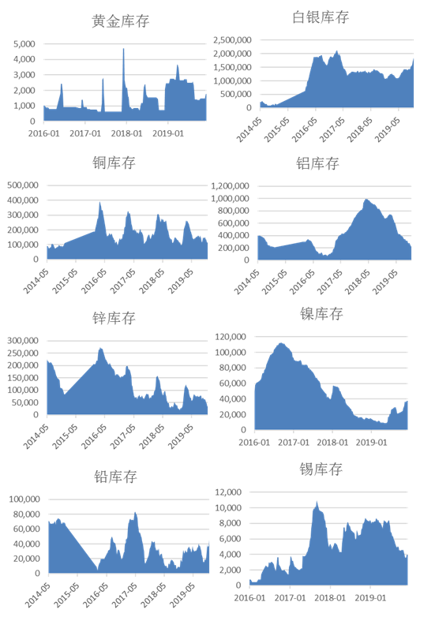

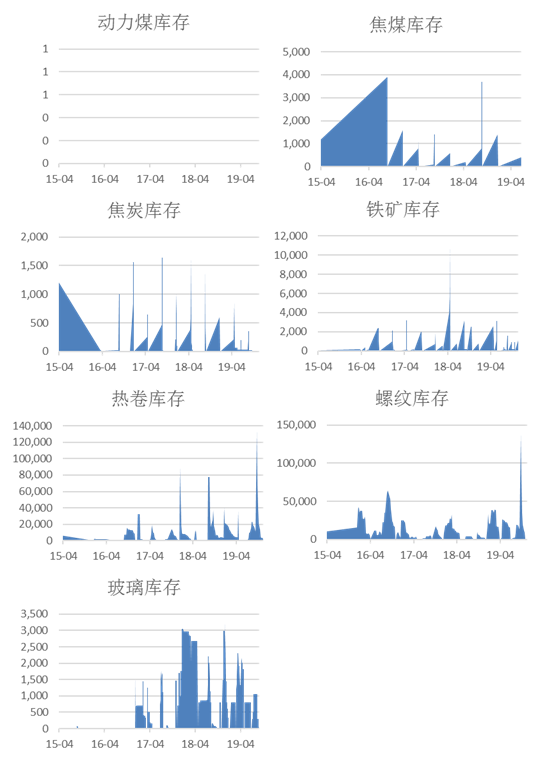

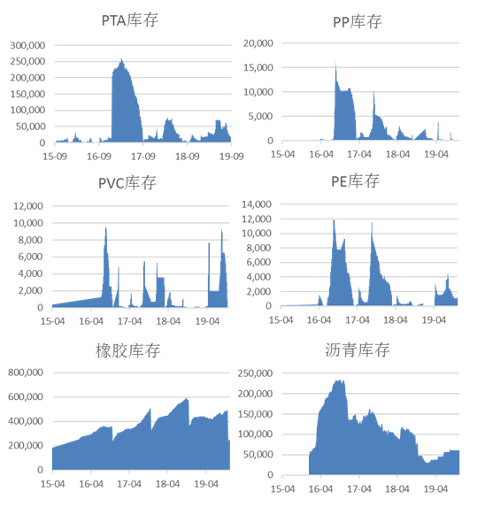

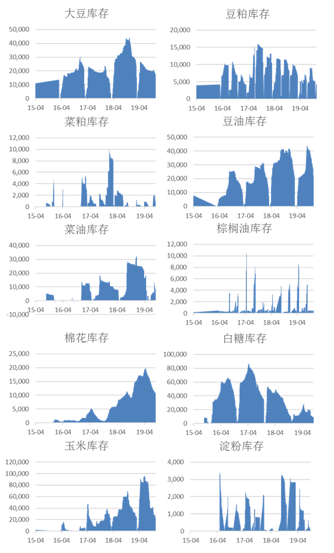

### 库存情况总结：

**对于明显高库存品种，尽量不做多。对于明显低库存品种，尽量不做空。**  
同时给出程序统计的库存水位序列如下：

| 有色 | 五年最小 | 五年最大 | 黑色建材 | 五年最小 | 五年最大 |
| --- | --- | --- | --- | --- | --- |
| 黄金 | 621 | 4704 | 动力煤 | 0 | 0 |
| 白银 | 80501 | 2136820 | 焦煤 | 0 | 3900 |
| 铜 | 74336 | 394777 | 焦炭 | 0 | 1640 |
| 铝 | 72155 | 993207 | 铁矿 | 0 | 10600 |
| 锌 | 20103 | 274320 | 热卷 | 0 | 132532 |
| 镍 | 8821 | 112085 | 螺纹 | 0 | 136555 |
| 铅 | 4052 | 83622 | 玻璃 | 0 | 3185 |
| 锡 | 433 | 10964 |  |  |  |

[output not shown]

### 2）全品种季节因子数据统计

关于各个品种的季节因子统计，我们的计算相对简单。首先我们计算出每个品种的指数价格走势，然后我们基于指数价格走势计算出月度改变百分比作为该品种的月度回报。最后我们以月为单位对过去五年之间的所有回报的正负进行统计，最终得到月度回报正负频率，最为月度回报的概率，也就是季节因子。在模型中，我们并不会讲这个变量作为主要考量变量，他的作用主要是回避明显的逆季节开仓。比如某个品种过去五年的一月份都是上涨的，那么我们尽量在一月份不要开仓做空，因为大概率这种上涨是季节性导致的。

### 全品种月度上涨概率 （2014---2019）

| 品种 | 一月 | 二月 | 三月 | 四月 | 五月 | 六月 | 七月 | 八月 | 九月 | 十月 | 十一月 | 十二月 |
| --- | --- | --- | --- | --- | --- | --- | --- | --- | --- | --- | --- | --- |
| 黄金 | 50% | 50% | **0%** | 50% | **17%** | **83%** | 67% | 67% | **17%** | 33% | 50% | **100%** |
| 白银 | 67% | 50% | 33% | 50% | **17%** | 67% | 33% | 50% | **17%** | 50% | **0%** | 67% |
| 铜 | 33% | 50% | 50% | **83%** | 33% | **83%** | **17%** | 33% | 50% | 67% | **17%** | 50% |
| 铝 | 33% | 50% | 67% | **83%** | 33% | 50% | 67% | 67% | **17%** | **17%** | **17%** | 50% |
| 锌 | 50% | 50% | 67% | 50% | 33% | 50% | 50% | 33% | **83%** | 67% | **17%** | 67% |
| 镍 | 75% | 75% | **0%** | 60% | 40% | **80%** | 60% | 40% | 60% | 60% | 20% | 60% |
| 铅 | 50% | 33% | 17% | 50% | 33% | **83%** | **83%** | **83%** | 50% | 33% | **17%** | 33% |
| 锡 | **100%** | 50% | 25% | 40% | 40% | 60% | **80%** | 20% | **80%** | 40% | 20% | **80%** |
| 动力煤 | **100%** | 75% | 50% | 75% | 50% | 80% | 40% | 40% | 60% | **20%** | 40% | **25%** |
| 焦煤 | 33% | **83%** | 33% | 50% | 50% | 50% | 67% | 67% | 33% | 33% | 50% | 33% |
| 焦炭 | 33% | 67% | 33% | 67% | 50% | 50% | 67% | 67% | **17%** | 50% | 50% | 50% |
| 铁矿 | 33% | *83%* | 33% | 67% | 50% | *83%* | 67% | *17%* | 33% | 50% | 50% | 83% |
| 热卷 | 60% | 60% | 20% | 50% | 33% | 67% | 50% | 50% | **0%** | 33% | 67% | 67% |
| 螺纹 | 67% | 67% | 33% | 67% | 33% | **83%** | 50% | 50% | **0%** | 67% | 50% | 50% |
| 玻璃 | **100%** | 80% | 20% | 40% | 80% | 80% | 40% | 40% | 20% | 80% | 40% | 75% |
| PTA | 75% | 60% | 20% | 60% | 40% | 80% | 40% | 60% | 40% | 60% | 40% | 75% |
| PP | 80% | 40% | 50% | 50% | 33% | **83%** | **83%** | 33% | 50% | **17%** | 33% | 33% |
| PVC | 67% | 33% | 50% | **83%** | 33% | 50% | 50% | 33% | 33% | **17%** | 33% | 50% |
| PE | 67% | 33% | 50% | 33% | 33% | 67% | 50% | **17%** | **17%** | 33% | **17%** | 33% |
| 橡胶 | **17%** | 50% | 33% | 67% | 50% | 50% | **0%** | 67% | **17%** | 50% | 50% | **100%** |
| 沥青 | 50% | 67% | 67% | 67% | **17%** | 83% | 50% | **17%** | 50% | 33% | 50% | 67% |
| 甲醇 | 50% | 60% | 40% | 80% | **20%** | 80% | 40% | 60% | 40% | **20%** | 40% | **100%** |
| 大豆 | 50% | **17%** | 33% | **83%** | 67% | 50% | 33% | 83% | 50% | 33% | 33% | 50% |
| 豆粕 | 50% | 50% | 50% | **100%** | 50% | 67% | 50% | **17%** | 50% | 67% | 33% | **0%** |
| 菜粕 | 75% | 60% | 60% | 40% | 40% | 80% | 60% | 20% | 40% | 60% | 40% | 50% |
| 豆油 | 33% | 67% | 33% | 67% | 50% | 50% | 50% | 67% | 33% | **83%** | 50% | 50% |
| 菜油 | 25% | 20% | 40% | 80% | 60% | 60% | 40% | 80% | 40% | 60% | 60% | 25% |
| 棕榈油 | **17%** | 67% | **17%** | 50% | 33% | 33% | 33% | 67% | 50% | 67% | 33% | 50% |
| 棉花 | 75% | 60% | 20% | **100%** | 40% | 40% | 20% | 20% | 40% | 40% | 60% | 50% |
| 白糖 | 50% | 40% | 40% | 60% | 60% | 40% | 20% | 40% | 80% | 80% | 40% | **0%** |
| 玉米 | 67% | 50% | **17%** | 33% | 67% | 50% | **17%** | 67% | 33% | 67% | 50% | **17%** |
| 淀粉 | 80% | 60% | 40% | 40% | 60% | 40% | 20% | 40% | 20% | 60% | 60% | 20% |

- 从上表中可以明显看出，部分品种的季节性规律还是很明显的，已经加粗的部分是我们认为明显产生季节性因素的部分，可以在后期趋势策略时候加以利用。
- 同时我们可以从上表生成以下概率矩阵，作为之后的回测程序的一个输入变量。

```python
#Probability matrix
Prob_Mat = { "au":[0.5,0.5,0,0.5,0.17,0.83,0.67,0.67,0.17,0.33,0.5,1],
             "ag":[0.67,0.5,0.33,0.5,0.17,0.67,0.33,0.5,0.17,0.5,0,0.67],
             "cu":[0.33,0.5,0.5,0.83,0.33,0.83,0.17,0.33,0.5,0.67,0.17,0.5],
             "al":[0.33,0.5,0.67,0.83,0.33,0.5,0.67,0.67,0.17,0.17,0.17,0.5],
             "zn":[0.5,0.5,0.67,0.5,0.33,0.5,0.5,0.33,0.83,0.67,0.17,0.67],
             "ni":[0.75,0.75,0,0.6,0.4,0.8,0.6,0.4,0.6,0.6,0.2,0.6],
             "pb":[0.5,0.33,0.17,0.5,0.33,0.83,0.83,0.83,0.5,0.33,0.17,0.33],
             "sn":[1,0.5,0.25,0.4,0.4,0.6,0.8,0.2,0.8,0.4,0.2,0.8],
             "ZC":[1,0.75,0.5,0.75,0.5,0.8,0.4,0.4,0.6,0.2,0.4,0.25],
             "jm":[0.33,0.83,0.33,0.5,0.5,0.5,0.67,0.67,0.17,0.5,0.5,0.5],
             "j":[0.33,0.67,0.33,0.67,0.5,0.5,0.5,0.67,0.67,0.17,0.5,0.5,0.5],
             "i":[0.33, 0.83,0.33, 0.67,0.50,0.83,0.67,0.17,0.33,0.50,0.50,0.83],
             "hc":[0.6,0.6,0.2,0.5,0.33,0.67,0.5,0.5,0,0.33,0.67,0.67],
             "rb":[0.67,0.67,0.33,0.67,0.33,0.83,0.5,0.5,0,0.67,0.5,0.5],
             "FG":[1,0.8,0.2,0.4,0.8,0.8,0.4,0.4,0.2,0.8,0.4,0.75],
             "TA":[0.75,0.6,0.2,0.6,0.4,0.8,0.4,0.6,0.4,0.6,0.4,0.75],
             "pp":[0.8,0.4,0.5,0.5,0.33,0.83,0.83,0.33,0.5,0.17,0.33,0.33],
             "pvc":[0.67,0.33,0.5,0.83,0.33,0.5,0.5,0.33,0.33,0.17,0.33,0.5],
             "pe":[0.67,0.33,0.5,0.33,0.33,0.67,0.5,0.17,0.17,0.33,0.17,0.33],
             "ru":[0.17,0.5,0.33,0.67,0.5,0.5,0,0.67,0.17,0.5,0.5,1],
             "bu":[0.5,0.67,0.67,0.67,0.17,0.83,0.5,0.17,0.5,0.33,0.5,0.67],
             "MA":[0.5,0.6,0.4,0.8,0.2,0.8,0.4,0.6,0.4,0.2,0.4,1],
             "a":[0.5,0.17,0.33,0.83,0.67,0.5,0.33,0.83,0.5,0.33,0.33,0.5],
             "m":[0.5,0.5,0.5,1,0.5,0.67,0.5,0.17,0.5,0.67,0.33,0],
             "RM":[0.75,0.6,0.6,0.4,0.4,0.8,0.6,0.2,0.4,0.6,0.4,0.5],
             "y":[0.33,0.67,0.33,0.67,0.5,0.5,0.5,0.67,0.33,0.83,0.5,0.5],
             "OI":[0.25,0.2,0.4,0.8,0.6,0.6,0.4,0.8,0.4,0.6,0.6,0.25],
             "p":[0.17,0.67,0.17,0.5,0.33,0.33,0.33,0.67,0.5,0.67,0.33,0.5],
             "CF":[0.75,0.6,0.2,1,0.4,0.4,0.2,0.2,0.4,0.4,0.6,0.5],
             "SR":[0.5,0.4,0.4,0.6,0.6,0.4,0.2,0.4,0.8,0.8,0.4,0],
             "c":[0.67,0.5,0.17,0.33,0.67,0.5,0.17,0.67,0.33,0.67,0.5,0.17],
             "cs":[0.8,0.6,0.4,0.4,0.6,0.4,0.2,0.4,0.2,0.6,0.6,0.2],
             }
```

### 3）宏观因素，历史因子和盘面因子综合分析

回测依据2018年末的行情，对2019年的行情进行检测。首先我们假设现在的时间是2018年末，回顾中国在2018年末的宏观指标如下：

### 宏观经济指标概览（2014-2018）

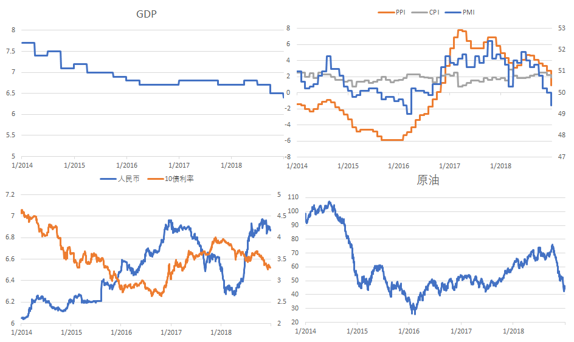

- **GDP和PMI稳定下行**，仍然维持在$6.5%$左右，经济有可能有硬着陆风险。
- **CPI稳定在2%但是PPI明显走弱临近0%**，工业品价格在2019年有较大的下行压力。
- **利率走势下行趋势**，长期利率处在下行通道，预计2019继续下跌。
- **人民币贬值通道良好**，短期人民币有走强趋势，但是长期来看空头趋势良好。
- **原油价格空头趋势良好**，原油第四季度再次暴跌，预计2019年维持低位震荡。

叠加2018年末时期的库存总体偏高，但是在持续下降：

- 明显低库存品种：黄金，铜，锌，镍，铅，沥青，PTA，PP，PE，菜粕，菜油，棕榈油，白糖。
- 明显高库存品种：白银，锡，焦炭，热卷，玻璃，橡胶，大豆，豆粕，豆油，菜油，棉花，玉米，淀粉。

总体来讲19年总体看空，对高库存品种做空，少量参与低库存品种的做多为主。下面我们结合宏观分析进行策略回测：

- 全年商品操作重心做空工业品为主，我们采用对做空策略顺势加仓，做多策略不加仓的操作方式。
  - **做空目标**：白银，锡，焦炭，热卷，玻璃，橡胶，大豆，豆粕，豆油，菜油，棉花，玉米，淀粉。
  - **做多目标**：黄金，铜，锌，镍，铅，沥青，菜粕，菜油，棕榈油，白糖。

下面我们进行盘面因子的建立，这里我们考虑以下三个盘面因子：**价格因子，基差因子和股票因子**。

下面我们进行股票因子的构建，参考下图关于对应商品指数追踪表：

### 股票因子组成表

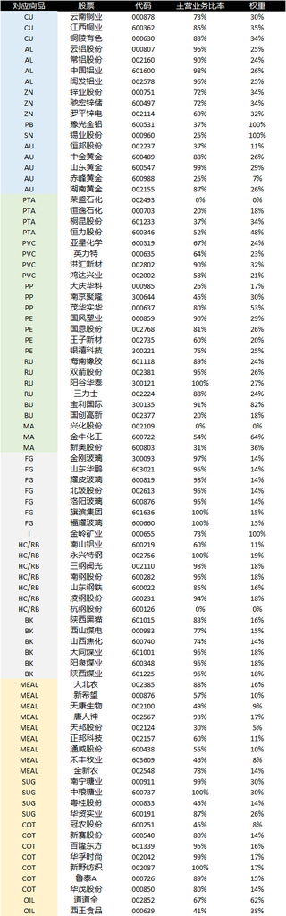

### 4）策略回测

回测组合范围：

做多和做空信号的定义如下（*已经经过了宏观因素和库存因子的筛选后的信号）：

出场信号：

- **价格破位生命线**
- **或者利润回吐30%**

```python
# First import dependent library
import pandas as pd
import datetime as dt
import matplotlib.dates as mdates
from matplotlib import pyplot as plt
import warnings
warnings.filterwarnings('ignore') # Turnoff warnings
%matplotlib inline
```

```python
# Backtesting helper function
def single_signal( df, LorS, Prob_li, codes, drawdown ):
    # Inputs: 1.dataframe with dates,price_index,roll yield
    #         2.LorS = Long or Short
    #         3.Prob_li = probability matrix list with month and long probability
    #         4.Codes = (1)price_name,(2)roll_yield name,(3)stock_index name
    # Outputs: List of returns defined by strategy ordered with dates.
    N = 55 # Rolling days
    df[codes[0]+"_55"] = df[codes[0]].rolling(N).mean()
    df[codes[2]+"_55"] = df[codes[2]].rolling(N).mean()
    start = df.index.searchsorted(dt.datetime(2019, 1, 1))
    end = df.index.searchsorted(dt.datetime(2019, 12, 31))
    df = df.iloc[start:end]
    df["signal"] = 0
    df["max_down"] = 0
    signal   = 0
    m_price  = 0 # remember running max or min price
    s_price  = 0
    max_down = 0
    flag     = 0
    for i in range(1,len(df)):
        row = df.iloc[i]
        pre_row = df.iloc[i-1]
        if row[codes[0]+"_55"]<row[codes[0]] and pre_row[codes[0]+"_55"]>=pre_row[codes[0]]\
            and row[codes[2]+"_55"]<=row[codes[2]] \
            and row[codes[1]]<=0.03 and LorS == 1:
            s_price = row[codes[0]]
            m_price = row[codes[0]]
            signal = 1
            flag = 1
        elif row[codes[0]+"_55"]>row[codes[0]] and pre_row[codes[0]+"_55"]<=pre_row[codes[0]]\
            and row[codes[2]+"_55"]>=row[codes[2]] \
            and row[codes[1]]>=0.05 and LorS == -1:
            s_price = row[codes[0]]
            m_price = row[codes[0]]
            signal = -1
            flag = -1
        # Max_down:Exit condition if profit giveback large than 30%
        elif flag == 1 and (row[codes[0]+"_55"]>row[codes[0]] and pre_row[codes[0]+"_55"]<=pre_row[codes[0]]\
            or max_down>=drawdown):
            signal = -1
            flag = 0
            m_price = row[codes[0]]
        elif flag == -1 and (row[codes[0]+"_55"]<row[codes[0]] and pre_row[codes[0]+"_55"]>=pre_row[codes[0]]\
            or max_down>=drawdown):
            signal = 1
            flag = 0
            m_price = row[codes[0]]
        else:
            signal = 0

        if s_price == m_price:
            max_down = 0
        else:
            max_down = abs(row[codes[0]]-m_price)/abs(s_price-m_price)
        m_price = LorS*max(LorS*m_price,LorS*row[codes[0]])
        df.set_value(df.iloc[i].name, 'signal', signal)
        df.set_value(df.iloc[i].name, 'max_down', max_down)
    ans = df[[codes[0],"signal","max_down"]].rename(columns={codes[0]: "Price"})
    return ans
#Portfolio return calculation
def cal_return(df):
    # Inputs: 1.DataFrame with Price and signal
    # Output: Return list on daily basis
    df["signal"] = df["signal"].cumsum()
    df["Returns"] = df["Price"].pct_change()*df["signal"]
    df["NAV"] = (1+df["Returns"]).cumprod(skipna=True)
    return df
```

```python
future = pd.read_excel("future_data.xlsx").set_index("Dates")
stock = pd.read_excel("stock_data.xlsx").set_index("Dates")
merged = pd.merge(future, stock, how='inner', left_index=True, right_index=True).fillna(method='ffill')
merged = merged.dropna()
drawdown = 0.3 #Exit position when hit drawdown level
code_li = [["P_au","RY_au","AU"],["P_ag","RY_ag","AU"],["P_cu","RY_cu","CU"],["P_zn","RY_zn","ZN"],
           ["P_ni","RY_ni","blank"],["P_pb","RY_pb","PB"],["P_sn","RY_sn","SN"],["P_j","RY_j","BK"],
           ["P_hc","RY_hc","HR"],["P_FG","RY_FG","FG"],["P_ru","RY_ru","RU"],["P_bu","RY_bu","BU"],
           ["P_a","RY_a","blank"],["P_m","RY_m","MEAL"],["P_y","RY_y","FOOD_OIL"],["P_OI","RY_OI","FOOD_OIL"],
           ["P_CF","RY_CF","COTTON"],["P_SR","RY_SR","SUGAR"],["P_c","RY_c","blank"],
           ["P_cs","RY_cs","blank"]]
LorS = {"P_au":1,"P_ag":-1,"P_cu":1,"P_zn":1,"P_ni":1,"P_pb":1,
        "P_sn":-1,"P_j":-1,"P_hc":-1,"P_FG":-1,"P_ru":-1,"P_bu":1,"P_a":-1,
        "P_m":-1,"P_y":-1,"P_OI":-1,"P_CF":-1,"P_p":1,"P_SR":1,"P_c":-1,"P_cs":-1}
Prob_Mat = Prob_Mat
Portfolio = pd.DataFrame(index=merged.index)
for code in code_li:
    signal = single_signal(merged[code],LorS[code[0]],Prob_Mat[code[0].split("_")[1]],code,drawdown)
    rets = cal_return(signal)
    Portfolio[code[0].split("_")[1]] = rets["Returns"]
Portfolio = Portfolio.dropna()
Portfolio["Position"] = (Portfolio != 0).sum(1)
Portfolio["P_Return"] = Portfolio.iloc[:, :-1].sum(axis=1)*0.2
Portfolio["NAV"] = (1+Portfolio["P_Return"]).cumprod(skipna=True)
```

下图是使用如上策略历史回测的资金曲线，可以看到2019年如果使用宏观过滤之后的不加仓的趋势追踪策略是可以取得**超过20%**的投资回报的。

对于持仓情况，**最高峰持仓数量为4个不同品种**，也是完全在策略规定内的。

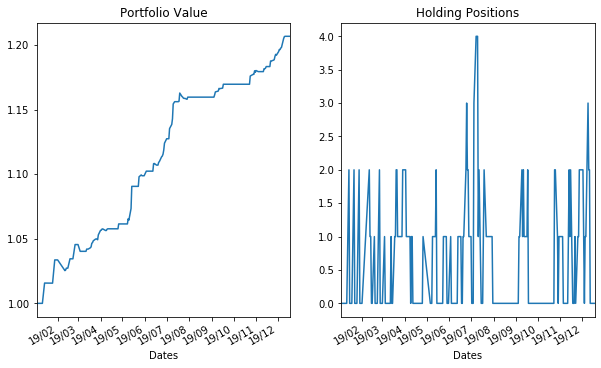

```python
myFmt = mdates.DateFormatter('%y/%m')
fig, ax = plt.subplots(nrows=1, ncols=2, figsize=(10,6))
Portfolio["NAV"].plot(ax = ax[0])
Portfolio["Position"].plot(ax = ax[1])
ax[0].title.set_text('Portfolio Value')
ax[1].title.set_text('Holding Positions')
ax[0].xaxis.set_major_formatter(myFmt)
ax[1].xaxis.set_major_formatter(myFmt)
```

## 资金管理

以上的策略展示都是没有融入仓位管理考虑的，但是实战中仓位管理是极其重要的一部分，在一个趋势程度强的行情中，往往能够持续长达数月之久，那么中途加仓会极大地提高收益率。相反的行情要是很短命，那么最好的操作就是等待清仓离场。往往一个简单地策略可以取得正的回报，但是这种回报率往往很低，采取仓位管理可以很好地增大回报，就是所谓的抓住大行情。

这里的仓位管理方法，主要基于对行情生命长度的预期决定的，很多人会说加仓的方式应该取决于行情波动幅度的预期，但是所有的趋势追踪模型有一个前提假设就是不给行情的幅度设置预期，而是采用跟踪止盈或者止损的方法尽量长的参与行情趋势之中。

不预设行情可能的幅度就不会影响行情最终参与程度，也就可以很好地让一套趋势系统实现"让盈利的奔跑"，这一最终目的。

我们对行情的生命周期判断主要依靠宏观变量配合当下品种库存来决定。首先从宏观上决定每一年的行情出现可能性，然后基本可以确定概念爆发大行情的可能性是否够高，从而对行情在该年生命周期有个分类和预期。

具体的分类方法我们使用宏观分析的方法，对于商品总体的价格预期主要取决于通胀预期和供需情况最后叠加一些金融属性，对于不同的品种金融属性差别很大所以金融属性并不在我们的主要考量范围。但是在对个体品种的判断上，金融属性是会占有很大比重的。

- 通胀预期判断基于一系列经济指标的宏观分析：GDP、PMI、PPI、CPI、人民币，利率、原油。
- 供需情况：商品对应股票预期，商品总体库存情况。

结论可能性分成三种情况：

- 大概率：每一次行情进行三次加仓操作，每次加仓为目前持仓的一倍。
- 一般：每次行情进行一次加仓操作，加仓为目前持仓的一倍。
- 小概率：每次行情不进行加仓操作，等待获利止盈或破位止损。

判断标准如下：

- 大概率：高通胀预期+高需求预期+低总体库存，低通胀预期+低需求预期+高总体库存。
- 小概率：高通胀预期+高总体库存，低通胀预期+低总体库存。
- 一般：其他所有情况均属于一般情况。

## 2020操作展望和策略

### 中国最近五年宏观经济指标

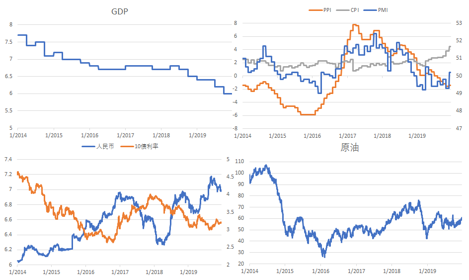

- **GDP和PMI稳定下行**，仍然维持在$6%$左右，经济没有硬着陆风险但是持续下行已成定局，未来总需求仍将保持缓慢下坡态势。
- **CPI与PPI形成明显剪刀差**，居民消费物价维持强劲上行态势，同时工业品出厂价格跌入冰点。影响商品板块明显分化走势。
- **利率走势开始筑底**，叠加高CPI预计明年利率下行空间有限。
- **人民币贬值通道良好**，预计明年延续贬值趋势。会有部分输入性通胀影响，主要看人民币价格是否出现大幅贬值，目前状况不太可能因为本币贬值传导通胀成为交易主要逻辑。
- **原油价格持续底部徘徊**，从16年开始没有趋势行情，明年受到新增供给和边际需求减弱的影响下，除非有事件冲击，大概率维持弱势震荡格局。

### 商品总体库存情况

商品总体库存情况，这里我们还是使用交易所最近五年库存数据对比当前的库存水平确定库存周期位置。我们可以直接从之前的库存分析图看出来，目前的商品总体库存处在相对低位，给了商品总体价格一个托底支撑。

参考之前的库存追踪，结论如下：

- 明显低库存品种：铝，锌，玻璃，PTA，PP，PE，沥青，菜粕，菜油，棕榈油，白糖，淀粉。
- 明显高库存品种：白银，锡，螺纹（突发库存），热卷（突发库存），PVC，橡胶，大豆，豆油，棉花，玉米。

### 结论：

#### 2020爆发大行情：小概率

对于2020年的展望，通胀预期分化严重：对于食品端以CPI为代表的通胀将会持续在高位，从猪肉涨价开始的通胀会传播到整个板块导致CPI维持相对高位。对于工业品端以PPI为代表的通胀将会持续疲软，工业品端的通胀会有部分通缩风险。再看总体库存情况：工业品端的库存经过严厉的去库存之后已经达到相对底部，进一步下行可能性不大，食品端的库存长期来看基本稳定，短期的供给主要取决于天气和政府干预。所以2020年的商品总体表现为震荡为主，工业品持续下行但是受到低库存托底，农产品受到通胀影响但是供应充足，有国家政策封顶。